# Análisis geoespacial

2017-08-11

## Datos espaciales

- Datos que representan ubicaciones, formas y tamaños de entidades en el planeta.
- Generalmente acompañados de atributos o metadatos.
- Inicialmente desarrollados para sistemas de información geográfica.
- Por ejemplo, el marco geoestadístico de México

Estos objetos representan un reto para la ciencia de datos, ya que su almacenamiento y procesamiento no se realiza de manera convencional debido a su estructura.

## Estructura de datos espaciales

- Datos vectoriales:
  - Puntos: Dimensión 1. Cada punto es representado por un par de codenadas (x, y).
  - Líneas: Dimensión 2. Múltiples puntos conectados en un orden.
  - Polígonos: Dimensión 2. Múltiples líneas conectadas. Estas líneas no se intersectan y la última línea debe terminar en el inicio de la primera.
- Datos raster: Representan mediciones sobre un espacio geográfico. Estas mediciones son agrupadas en celdas que conforman una grilla. Cada celda debe representar las mediciones en el área que abarque. El tamaño de la celda da la propiedad de resolución.

## Soporte en software

- GIS:
  - ArcGIS
  - OpenGIS
  - GRASS
  - QGIS
- Bases de datos espaciales:
  - PostGIS
  - SQL Server
  - MySQL
  - Redis
- Lenguajes de programación:
  - Python (shapely, geopy, ogr/gdal)
  - C++ (GEOS, GDAL)
  - Java (GeoTools)
  - Scala (GeoSparkl, SpatialSpark)
  - R

## Librerías en R

- Data structures
  - sp
  - sf
  - raster
- Manipulation
  - rgdal
  - rgeos
  - maptools
  - geosphere
- Visualizaton
  - ggplot2
  - ggmap
  - leaflet
  - plotkml

Más en la siguiente liga

## Instalación

```r
pkgs <- c(
  "magrittr", "Rcpp", "data.table", "sp", "raster", "sf", "rgdal", "geosphere",
  "dismo", "maps", "maptools", "ggplot2", "ggmap", "jsonlite"
)
# install.packages(pkgs, repos = "https://cran.itam.mx/")
sapply(pkgs, require, character.only = TRUE)
```

```
##   magrittr       Rcpp data.table         sp     raster         sf      rgdal  geosphere      dismo
##       TRUE       TRUE       TRUE       TRUE       TRUE       TRUE       TRUE       TRUE       TRUE
##       maps   maptools    ggplot2      ggmap   jsonlite
##       TRUE       TRUE       TRUE       TRUE       TRUE
```

## Dependencias en CRAN

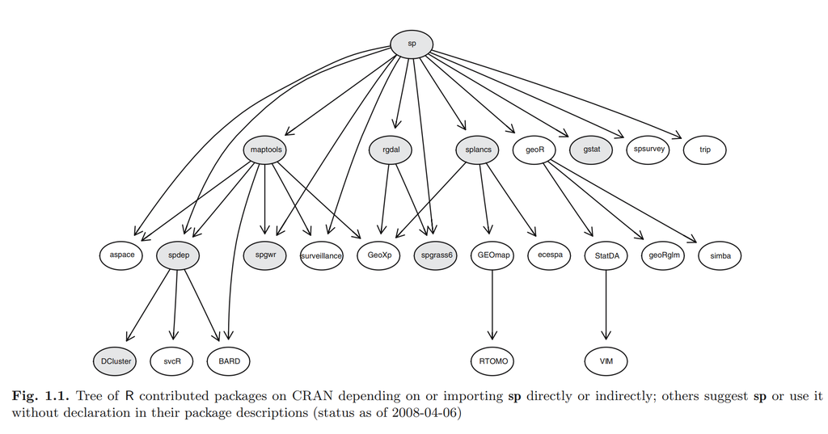

## Data structures

## Librerías con estructuras de datos espaciales

### Clases de datos vectoriales en R

- sp: Librería estándar para manipulación de datos vectoriales en R.
- sf: Experimental. Sigue el estándar ISO 19125-1:2004.

### Clases de datos raster en R

- sp: clase `SpatialGrid*`
- raster: clases `Raster*`

## `sp`: Classes and methods for spatial data

La librería da soporte a las clases:

- `CRS`
- `SpatialPoints*`
- `SpatialLines*`
- `SpatialMultiPoints*`
- `SpatialPolygons*`
- `SpatialGrid*`
- `SpatialPixels*`

Todas estas clases están acompañadas de un constructor que permite incluir los metadatos en forma de un data.frame. Por ejemplo, `SpatialPointsDataFrame` recibe como argumento adicional los metadatos para cada punto.

## SpatialPoints

- Por convención el formato default para coordenadas es (lon, lat).
- Además de especificar las coordenadas necesitamos especificar un CRS.

```r
example_crs <- CRS("+proj=longlat +datum=WGS84") # Creamos el sistema de coordenadas
example_points <- data.frame(                    # Creamos un data.frame con 10 coordenadas
  longitud = runif(10, -118, -87),               # Nota: La primera columna es la longitud
  latitud = runif(10, 15, 32)
)
(spatial_points <- SpatialPoints(coords = example_points, proj4string = example_crs))
```

```
## class       : SpatialPoints
## features    : 10
## extent      : -110.8334, -89.48548, 19.38391, 30.2827  (xmin, xmax, ymin, ymax)
## coord. ref. : +proj=longlat +datum=WGS84 +ellps=WGS84 +towgs84=0,0,0
```

## Métodos de `Spatial*`

`bbox` devuelve el **bounding box** o coordenadas extremas.

```r
bbox(spatial_points)
```

```
##                 min       max
## longitud -110.83341 -89.48548
## latitud    19.38391  30.28270
```

`summary` devuelve el bounding box, el número de puntos y la proyección.

```r
summary(spatial_points)
```

```
## Object of class SpatialPoints
## Coordinates:
##                 min       max
## longitud -110.83341 -89.48548
## latitud    19.38391  30.28270
## Is projected: FALSE
## proj4string :
## [+proj=longlat +datum=WGS84 +ellps=WGS84 +towgs84=0,0,0]
## Number of points: 10
```

## Métodos de `Spatial*` (cont.)

`proj4string` devuelve el string de proyección:

```r
proj4string(spatial_points)
```

```
## [1] "+proj=longlat +datum=WGS84 +ellps=WGS84 +towgs84=0,0,0"
```

`coordinates` devuelve las coordenadas de los puntos:

```r
coordinates(spatial_points)
```

```
##         longitud  latitud
##  [1,]  -90.61517 30.28270
##  [2,] -103.16205 23.45151
##  [3,] -110.05192 19.38391
##  [4,] -110.83341 22.83787
##  [5,]  -89.48548 22.02785
##  [6,] -102.92660 29.91612
##  [7,] -102.68402 24.73128
##  [8,]  -92.19951 21.12911
##  [9,] -109.83462 24.14086
## [10,]  -97.81363 23.52496
```

## `SpatialPointsDataFrame`

Las clases `*DataFrame` crean objetos espaciales con metadatos adjuntos en un objeto `data.frame`.

```r
metadata <- data.frame(random_name = sample(LETTERS, 10))
spatial_points_df <- SpatialPointsDataFrame(
  coords = spatial_points,
  data = metadata,
  proj4string = example_crs
)
str(spatial_points_df)
```

```
## Formal class 'SpatialPointsDataFrame' [package "sp"] with 5 slots
##   ..@ data       :'data.frame':  10 obs. of  1 variable:
##   .. ..$ random_name: Factor w/ 10 levels "D","F","J","K",..: 3 6 5 9 7 4 2 10 1 8
##   ..@ coords.nrs : num(0)
##   ..@ coords     : num [1:10, 1:2] -90.6 -103.2 -110.1 -110.8 -89.5 ...
##   .. ..- attr(*, "dimnames")=List of 2
##   .. .. ..$ : NULL
##   .. .. ..$ : chr [1:2] "longitud" "latitud"
##   ..@ bbox       : num [1:2, 1:2] -110.8 19.4 -89.5 30.3
##   .. ..- attr(*, "dimnames")=List of 2
##   .. .. ..$ : chr [1:2] "longitud" "latitud"
##   .. .. ..$ : chr [1:2] "min" "max"
##   ..@ proj4string:Formal class 'CRS' [package "sp"] with 1 slot
##   .. .. ..@ projargs: chr "+proj=longlat +datum=WGS84 +ellps=WGS84 +towgs84=0,0,0"
```

## Métodos en `Spatial*DataFrame`

Estas clases procuran simular un objeto `data.frame` en lo más posible. Podemos usar los métodos:

- `merge`
- `summary`
- `dim`
- `head`
- `tail`
- `plot`
- `print`
- `rbind`
- `show`
- `subset`
- `$ (extract)`
- `[ (extract)`
- `[[ (extract)`

## `SpatialLines*`

Para crear objetos de clase `SpatialLines` requerimos una lista de objetos clase `Lines`, que a su vez está compuesto por objetos de clase `Line`, que finalmente está compuesto por coordenadas que forman segmentos.

```r
# Creamos 3 objetos Line y dos objetos Lines
line1 = Line(data.frame(runif(3, -118, -87), runif(3, 15, 32)))
line2 = Line(data.frame(runif(3, -118, -87), runif(3, 15, 32)))
line3 = Line(data.frame(c(-118, -87), c(15, 32)))
lines1 <- Lines(list(line1, line2), ID = "A")
lines2 <- Lines(list(line3), ID = "B")

metadata <- data.frame(row.names = c("A", "B"), name = letters[1:2])
spatial_lines <- SpatialLines(list(lines1, lines2), example_crs)          # Creamos un objeto SpatialLines
(spatial_lines_dataframe <- SpatialLinesDataFrame(spatial_lines, metadata)) # Agregamos metadatos
```

```
## class       : SpatialLinesDataFrame
## features    : 2
## extent      : -118, -87, 15, 32  (xmin, xmax, ymin, ymax)
## coord. ref. : +proj=longlat +datum=WGS84 +ellps=WGS84 +towgs84=0,0,0
## variables   : 1
## names       : name
## min values  :    a
## max values  :    b
```

## Métodos de `SpatialLines`

```r
LineLength(cc = line1, longlat = TRUE, sum = FALSE) # Retorna la longitud de cada segmento de la línea
```

```
## [1] 2100.203 1455.522
```

```r
LinesLength(Ls = lines2, longlat = TRUE)    # Retorna la suma de las longitudes de las lineas
```

```
## [1] 3662.645
```

```r
SpatialLinesLengths(SL = spatial_lines, longlat = TRUE) # Retorna la suma de las longitudes de las líneas
```

```
## [1] 6374.261 3662.645
```

```r
getSpatialLinesMidPoints(spatial_lines)   # Retorna un objeto SpatialPoints con los centros de las líneas
```

```
## class       : SpatialPoints
## features    : 2
## extent      : -102.5, -99.93291, 22.51271, 23.5  (xmin, xmax, ymin, ymax)
## coord. ref. : +proj=longlat +datum=WGS84 +ellps=WGS84 +towgs84=0,0,0
```

## Otros métodos en `SpatialLines`

- `[ (extract)`
- `coordinates`
- `plot`
- `lines`
- `rbind`
- `summary`

## `SpatialPolygons`

Al igual que `SpatialLines`, `SpatialPolygons` se contruye con una lista de objetos clase `Polygons`, que a su vez se componen de objetos de clase `Polygon`, que son objetos de clase `Line` cuya coordenada final es igual a la coordenada inicial.

```r
example_bounding_box <- data.frame(
  longitud = c(-118, -118, -87, -87, -118),
  latitud = c(15, 32, 32, 15, 15)
)
example_polygon <- Polygon(example_bounding_box)
example_polygons <- Polygons(srl = list(example_polygon), "bounding box")
(spatial_polygons <- SpatialPolygons(list(example_polygons), proj4string = example_crs))
```

```
## class       : SpatialPolygons
## features    : 1
## extent      : -118, -87, 15, 32  (xmin, xmax, ymin, ymax)
## coord. ref. : +proj=longlat +datum=WGS84 +ellps=WGS84 +towgs84=0,0,0
```

## `GridTopology`

Para crear un objeto de clase `SpatialGrid` necesitamos un objeto clase `GridTopology`. El cual requiere básicamente, un centro y el tamaño de las celdas.

```r
bb <- bbox(spatial_polygons)
cs <- c(0.5, 0.5)             # Tamaño de las celdas
cc <- bb[, 1] + cs / 2          # Cordenadas del centroide de inferior izquierdo de la grilla
cd <- ceiling(diff(t(bb))/cs)   # Total de celdas en cada dimensión
(example_topology <- GridTopology(cellcentre.offset = cc, cellsize = cs, cells.dim = cd))
```

```
##                         x     y
## cellcentre.offset -117.75 15.25
## cellsize             0.50  0.50
## cells.dim           62.00 34.00
```

## `SpatialGrid*` y métodos en `SpatialGrid*`

```r
example_grid <- SpatialGrid(example_topology, example_crs)
summary(example_grid)
```

```
## Object of class SpatialGrid
## Coordinates:
##    min max
## x -118 -87
## y   15  32
## Is projected: FALSE
## proj4string :
## [+proj=longlat +datum=WGS84 +ellps=WGS84 +towgs84=0,0,0]
## Grid attributes:
##   cellcentre.offset cellsize cells.dim
## x           -117.75      0.5        62
## y             15.25      0.5        34
```

```r
areaSpatialGrid(example_grid)
```

```
## [1] 527
```

Para el estudio de variables continuas se recomienda el uso de la librería `raster`.

## `raster`: Geographic Data Analysis and Modeling

La librería da soporte a las clases:

- `RasterLayer`
- `RasterBrick`
- `RasterStack`

## `RasterLayer`

Representa una sola capa de datos. Contiene información acerca del origen de los datos, el número de filas y columnas en la grilla.

```r
(example_raster <- raster(
  nrows = 180,       # Número de filas
  ncols = 360,       # Número de columnas
  xmn = -180,        # Coordenada x mínima
  xmx = 180,         # Coordenada x máxima
  ymn = -90,         # Coordenada y mínima
  ymx = 90,          # Coordenada y máxima
  crs = example_crs, # Sistema de coordenadas
  vals = runif(180 * 360)
))
```

```
## class       : RasterLayer
## dimensions  : 180, 360, 64800  (nrow, ncol, ncell)
## resolution  : 1, 1  (x, y)
## extent      : -180, 180, -90, 90  (xmin, xmax, ymin, ymax)
## coord. ref. : +proj=longlat +datum=WGS84 +ellps=WGS84 +towgs84=0,0,0
## data source : in memory
## names       : layer
## values      : 1.116493e-05, 0.9999876  (min, max)
```

## `RasterStack`

Estas clases dan soporte cuando tenemos múltiples capas raster. La diferencia es que `RasterBrick` solo puede ser referenciado a un solo origen y los `RasterStack` a múltiples.

```r
example_raster2 <- raster(
  nrows = 180, ncols = 360, xmn = -180, xmx = 180, ymn = -90,
  ymx = 90, crs = example_crs, vals = sort(rnorm(180 * 360))
)
(raster_stack <- stack(example_raster, example_raster2))
```

```
## class       : RasterStack
## dimensions  : 180, 360, 64800, 2  (nrow, ncol, ncell, nlayers)
## resolution  : 1, 1  (x, y)
## extent      : -180, 180, -90, 90  (xmin, xmax, ymin, ymax)
## coord. ref. : +proj=longlat +datum=WGS84 +ellps=WGS84 +towgs84=0,0,0
## names       :       layer.1,       layer.2
## min values  :  1.116493e-05, -4.070922e+00
## max values  :     0.9999876,     4.1950850
```

```r
(raster_brick <- brick(example_raster, example_raster2))
```

```
## class       : RasterBrick
## dimensions  : 180, 360, 64800, 2  (nrow, ncol, ncell, nlayers)
## resolution  : 1, 1  (x, y)
## extent      : -180, 180, -90, 90  (xmin, xmax, ymin, ymax)
## coord. ref. : +proj=longlat +datum=WGS84 +ellps=WGS84 +towgs84=0,0,0
## data source : in memory
## names       :       layer.1,       layer.2
## min values  :  1.116493e-05, -4.070922e+00
## max values  :     0.9999876,     4.1950850
```

## `sf`: Simple Features for R

Los **simple feature** son el estándar internacional de la representación y manipulación de datos espaciales. La ventaja de usar las **simple features** es intercompatibilidad entre lenguajes y bases de datos, además, el desempeño a mejorado bastante con respecto a `sp` (10x). Los tipos de datos más importantes soportados por `sf` son:

- `POINT`
- `LINESTRING`
- `POLYGON`
- `MULTIPOINT`
- `MULTILINESTRING`
- `MULTIPOLYGON`
- `GEOMETRYCOLLECTION`

## Clase `sf`

La clase `sf` representa un **single feature**. A su vez está compuesto por un `data.frame` que contiene los metadatos y un objeto de clase `sfc` (simple feature collection), que es una lista de objetos `sfg` (simple feature geometry).

```r
example_point <- st_point(c(0, 1))
example_line <- st_linestring(matrix(c(0, 1, 0, 1), 2, 2))
outer = matrix(c(0, 0, 10, 0, 10, 10, 0, 10, 0, 0), ncol = 2, byrow = TRUE)
pts = list(outer)
example_polygon <- st_polygon(pts)
class(example_polygon)
```

```
## [1] "XY"      "POLYGON" "sfg"
```

```r
(example_sfc <- st_sfc(example_polygon, example_line))
```

```
## Geometry set for 2 features
## geometry type:  GEOMETRY
## dimension:      XY
## bbox:           xmin: 0 ymin: 0 xmax: 10 ymax: 10
## epsg (SRID):    NA
## proj4string:    NA
```

## Clase `sf` (Cont.)

```r
(example_sf <- st_sf(a = 1:2, example_sfc))
```

```
## Simple feature collection with 2 features and 1 field
## geometry type:  GEOMETRY
## dimension:      XY
## bbox:           xmin: 0 ymin: 0 xmax: 10 ymax: 10
## epsg (SRID):    NA
## proj4string:    NA
##   a                    example_sfc
## 1 1 POLYGON((0 0, 10 0, 10 10, ...
## 2 2           LINESTRING(0 0, 1 1)
```

En este curso no profundizaremos mucho más en la librería `sf` ya que se encuentra en desarrollo.

## Geodata I/O

## Librerías

En esta sección ocuparemos las siguientes librerías: `sf` y `rgdal`.

```r
head(st_drivers(), 3)
```

```
##          name                  long_name write  copy is_raster is_vector
## PCIDSK PCIDSK       PCIDSK Database File  TRUE FALSE      TRUE      TRUE
## netCDF netCDF Network Common Data Format  TRUE  TRUE      TRUE      TRUE
## PDF       PDF             Geospatial PDF  TRUE  TRUE      TRUE      TRUE
```

```r
head(ogrDrivers(), 3)
```

```
##         name                long_name write  copy isVector
## 1 AeronavFAA              Aeronav FAA FALSE FALSE     TRUE
## 2     ARCGEN        Arc/Info Generate FALSE FALSE     TRUE
## 3     AVCBin Arc/Info Binary Coverage FALSE FALSE     TRUE
```

```r
head(gdalDrivers(), 3)
```

```
##      name                     long_name create  copy isRaster
## 1 AAIGrid           Arc/Info ASCII Grid  FALSE  TRUE     TRUE
## 2    ACE2                          ACE2  FALSE FALSE     TRUE
## 3    ADRG ARC Digitized Raster Graphics   TRUE FALSE     TRUE
```

## Recolectando datos

### Recolectando datos de bases de datos públicas

```r
coord_cols <- c("lon", "lat")
ab <- gbif(
  genus = "Ambystoma", species = "mexicanum",
  geo = TRUE, removeZeros = TRUE, ext = extent(c(-118, -87), c(15, 32))
)
ab_dt <- data.table(ab)
ab_points <- SpatialPointsDataFrame(
  coords = ab_dt[, coord_cols, with = FALSE],
  data = ab_dt[, -coord_cols, with = FALSE],
  proj4string = CRS("+proj=longlat +datum=WGS84")
)
ab_points
```

```
## class       : SpatialPointsDataFrame
## features    : 156
## extent      : -101.7333, -98.44167, 19.16194, 24.36667  (xmin, xmax, ymin, ymax)
## coord. ref. : +proj=longlat +datum=WGS84 +ellps=WGS84 +towgs84=0,0,0
## variables   : 116
## names       :   acceptedNameUsage,                            accessRights,             adm1,       adm2,                                                                                                                                                                                                …
## min values  : Ambystoma mexicanum, http://vertnet.org/resources/norms.html, Distrito federal,     CHALCO, Shaw, G. 1789. Gyrinus mexicanus. Nat. Misc. 9:PagCons: 343-344 PagPubl: ND Fuente: 2. Londres, Inglaterra. | Tihen, J. A. 1958. Comments on the osteology and phylogeny of Ambystomatid salama…
## max values  : Ambystoma mexicanum,                            Libre acceso,           Puebla, XOCHIMILCO, Shaw, G. 1789. Gyrinus mexicanus. Nat. Misc. 9:PagCons: 343-344 PagPubl: ND Fuente: 2. Londres, Inglaterra. | Tihen, J. A. 1958. Comments on the osteology and phylogeny of Ambystomatid salama…
```

## Recolectando datos (cont.)

### Datos a partir de la librería `maps`

```r
mexico_map <- map("world", "mexico", plot = FALSE)
(mexico_sl <- map2SpatialLines(mexico_map, proj4string = example_crs))
```

```
## class       : SpatialLines
## features    : 20
## extent      : -118.4014, -86.69629, 14.54541, 32.71533  (xmin, xmax, ymin, ymax)
## coord. ref. : +proj=longlat +datum=WGS84 +ellps=WGS84 +towgs84=0,0,0
```

### Líneas a partir de líneas de contorno

```r
(volcano_sl <- ContourLines2SLDF(contourLines(volcano)))
```

```
## class       : SpatialLinesDataFrame
## features    : 10
## extent      : 0, 1, 0, 1  (xmin, xmax, ymin, ymax)
## coord. ref. : NA
## variables   : 1
## names       : level
## min values  :   100
## max values  :   190
```

## Recolectando datos (cont.)

### Otras fuentes de información

- INEGI y CONABIO
- Global Administration Areas
- Global Biodiversity Information Facility y International Union for Conservation of Nature
- Open Street Map Data
- Natural Earth Data
- EarthExplorer - USGS
- Hydrosheds - USGS
- Copernicus Open Access Hub
- Open Topography
- Neo - NASA
- IPUMS Terra
- Food and Agriculture Organization of the UN
- United Nations Environment Programee
- SocioEconomic Data and Applications Center

## Importando datos con `sf`

### Shapefiles

```r
example_sf_shapefile <- st_read(system.file("shape/nc.shp", package = "sf"))
```

### KML

```r
example_sf_kml <- st_read("http://puebla.gob.mx/datos_abiertos/pueblos_magicos.kml")
```

## Importando datos con `sf`

### JSON

```r
example_sf_json <- st_read("files/mexico.json")
```

### Database Connections

```r
# st_read("PG:dbname=postgis", "meuse")
# st_read_db(conn, table, query, geom_column)
```

## Importando datos con `rgdal`

### Shapefiles

```r
example_sp_shapefile <- readOGR(system.file("shape", package = "sf"),"nc")
```

### KML

```r
example_sp_kml <- readOGR(
  dsn = "files/pueblos_magicos.kml",
  layer = "PlaceMarks"
)
```

## Importando datos con `rgdal` (cont.)

### JSON

```r
example_sp_json <- readOGR("files/mexico.json")
```

## Escribiendo datos

Con `sf`:

```r
# st_write(single_feature, "file.json")
# st_write(single_feature, "file.kml", delete_layer = TRUE)
# st_write(single_feature, "file.shp", delete_dns = TRUE)
# st_write_db(single_feature, update = TRUE)
```

Con `rgdal`:

```r
# writeOGR(spatial_object, "file.json", driver = "GeoJSON")
# writeOGR(spatial_object, "file.shp", driver = "ESRI Shapefile")
# writeOGR(spatial_object, "file.kml", driver = "KML")
# writeOGR(spatial_object, "file.dxf", driver = "AUTOCAD DFX")
```

## Manipulación y visualización de datos espaciales

## Librerías

En esta sección ocuparemos las siguientes librerías:

- `ggplot2`: Librería de graficación general
- `ggmap`: Extensión de ggplot2 para datos espaciales
- `leaflet`: Mapas interactivos
- `plotKML`: Exportar archivos KML con una buena manipulación del formato